# Project: Airbnb seattle data analysis

## Index

1. Pandas dataframe setting
2. Step 0: Load the Data
3. Step 1: Explore the data
   1. Take a look at the columns in the dataframes
   2. Check the data types of each of the columns
   3. Visualizing the missing values
      1. First we will focus on the calendar.csv data
      2. We'll focus on listings.csv
      3. Observations from missing values
4. Step 2.1 & 2.2 : Data prep and analysis for calendar.csv
   1. Analysis on rate of availibility of the listings
   2. Analysis on the price rate of the listings
   3. Observations from calendar.csv
5. Step 2.3 & 2.4 : Data prep and analysis for listings.csv
   1. We will first explore the spatial information using the seattle census tract data
   2. Checking the density of BNB's
   3. Observations for BNB density
   4. Exploring the type of bnbs on the basis of type, price, accomodation, rooms, beds
   5. Observations for type of listings
   6. Scatter plot for visualizing the density of the types of airbnbs in different regions of seattle
   7. Scatter plot observations
   8. Average price of BNB's in different tract of seattle
   9. Observations for Average price
6. Summarizing all the observations of the last section
7. Inferences from listings.csv

**The main buissness questions are mentioned in section 4. C. and section 7.**

```python
# import libraries here; add more as necessary
import numpy as np
import pandas as pd
import matplotlib.pyplot as plt
from matplotlib.pyplot import hist
import seaborn as sns
from IPython.display import display
import random
import math
from sklearn.impute import SimpleImputer
from sklearn.preprocessing import StandardScaler
from sklearn.decomposition import PCA
from helper_functions import show_images, do_pca, scree_plot, plot_component
from sklearn.cluster import KMeans
import missingno as msno
from datetime import datetime
import mplleaflet
import geopandas as gpd
import shapely
# magic word for producing visualizations in notebook
%matplotlib inline

'''
Import note: The classroom currently uses sklearn version 0.19.
If you need to use an imputer, it is available in sklearn.preprocessing.Imputer,
instead of sklearn.impute as in newer versions of sklearn.
'''
```

```
'\nImport note: The classroom currently uses sklearn version 0.19.\nIf you need to use an imputer, it is available in sklearn.preprocessing.Imputer,\ninstead of sklearn.impute as in newer versions of sklearn.\n'
```

# Pandas dataframe setting

This will help to view the whole dataframe, without omitting some of the rows and the columns go to index

```python
pd.set_option('display.width', 1000)
pd.set_option('max_columns', 500)
pd.set_option('display.max_rows', 500)
```

# Step 0: Load the Data

```python
# Load in the airbnb seattle calendar.csv
calendar_pd = pd.read_csv('././archive/calendar.csv',sep=",")

# Load in the airbnb seattle listings.csv.
listings_pd = pd.read_csv('././archive/listings.csv', sep=",")

# Load in the airbnb seattle reviews.csv.
reviews_pd = pd.read_csv('././archive/reviews.csv', sep=",")
```

# Step 1: Explore the data

```python
# Check the structure of the data after it's loaded (e.g. print the number of
# rows and columns, print the first few rows).
print(calendar_pd.shape, listings_pd.shape, reviews_pd.shape)
display(calendar_pd.head())
display(listings_pd.head())
display(reviews_pd.head())
```

```
(1393570, 4) (3818, 92) (84849, 6)
```

|  | listing_id | date | available | price |
| --- | --- | --- | --- | --- |
| 0 | 241032 | 2016-01-04 | t | $85.00 |
| 1 | 241032 | 2016-01-05 | t | $85.00 |
| 2 | 241032 | 2016-01-06 | f | NaN |
| 3 | 241032 | 2016-01-07 | f | NaN |
| 4 | 241032 | 2016-01-08 | f | NaN |

|  | id | listing_url | scrape_id | last_scraped | name | summary | space | description | experiences_offered | neighborhood_overview | notes | transit | thumbnail_url | medium_url | picture_url | xl_picture_url | host_id | host_url | host_name | host_since | host_location | host_about | host_response_time | host_response_rate | host_acceptance_rate | host_is_superhost | host_thumbnail_url | host_picture_url | host_neighbourhood | … |
| --- | --- | --- | --- | --- | --- | --- | --- | --- | --- | --- | --- | --- | --- | --- | --- | --- | --- | --- | --- | --- | --- | --- | --- | --- | --- | --- | --- | --- | --- | --- |
| 0 | 241032 | https://www.airbnb.com/rooms/241032 | 20160104002432 | 2016-01-04 | Stylish Queen Anne Apartment | NaN | Make your self at home in this charming one-be... | Make your self at home in this charming one-be... | none | NaN | NaN | NaN | NaN | NaN | https://a1.muscache.com/ac/pictures/67560560/c... | NaN | 956883 | https://www.airbnb.com/users/show/956883 | Maija | 2011-08-11 | Seattle, Washington, United States | I am an artist, interior designer, and run a s... | within a few hours | 96% | 100% | f | https://a0.muscache.com/ac/users/956883/profil... | https://a0.muscache.com/ac/users/956883/profil... | Queen Anne | … |
| 1 | 953595 | https://www.airbnb.com/rooms/953595 | 20160104002432 | 2016-01-04 | Bright & Airy Queen Anne Apartment | Chemically sensitive? We've removed the irrita... | Beautiful, hypoallergenic apartment in an extr... | Chemically sensitive? We've removed the irrita... | none | Queen Anne is a wonderful, truly functional vi... | What's up with the free pillows? Our home was... | Convenient bus stops are just down the block, ... | https://a0.muscache.com/ac/pictures/14409893/f... | https://a0.muscache.com/im/pictures/14409893/f... | https://a0.muscache.com/ac/pictures/14409893/f... | https://a0.muscache.com/ac/pictures/14409893/f... | 5177328 | https://www.airbnb.com/users/show/5177328 | Andrea | 2013-02-21 | Seattle, Washington, United States | Living east coast/left coast/overseas. Time i... | within an hour | 98% | 100% | t | https://a0.muscache.com/ac/users/5177328/profi... | https://a0.muscache.com/ac/users/5177328/profi... | Queen Anne | … |
| 2 | 3308979 | https://www.airbnb.com/rooms/3308979 | 20160104002432 | 2016-01-04 | New Modern House-Amazing water view | New modern house built in 2013. Spectacular s... | Our house is modern, light and fresh with a wa... | New modern house built in 2013. Spectacular s... | none | Upper Queen Anne is a charming neighborhood fu... | Our house is located just 5 short blocks to To... | A bus stop is just 2 blocks away. Easy bus a... | NaN | NaN | https://a2.muscache.com/ac/pictures/b4324e0f-a... | NaN | 16708587 | https://www.airbnb.com/users/show/16708587 | Jill | 2014-06-12 | Seattle, Washington, United States | i love living in Seattle. i grew up in the mi... | within a few hours | 67% | 100% | f | https://a1.muscache.com/ac/users/16708587/prof... | https://a1.muscache.com/ac/users/16708587/prof... | Queen Anne | … |
| 3 | 7421966 | https://www.airbnb.com/rooms/7421966 | 20160104002432 | 2016-01-04 | Queen Anne Chateau | A charming apartment that sits atop Queen Anne... | NaN | A charming apartment that sits atop Queen Anne... | none | NaN | NaN | NaN | NaN | NaN | https://a0.muscache.com/ac/pictures/94146944/6... | NaN | 9851441 | https://www.airbnb.com/users/show/9851441 | Emily | 2013-11-06 | Seattle, Washington, United States | NaN | NaN | NaN | NaN | f | https://a2.muscache.com/ac/users/9851441/profi... | https://a2.muscache.com/ac/users/9851441/profi... | Queen Anne | … |
| 4 | 278830 | https://www.airbnb.com/rooms/278830 | 20160104002432 | 2016-01-04 | Charming craftsman 3 bdm house | Cozy family craftman house in beautiful neighb... | Cozy family craftman house in beautiful neighb... | Cozy family craftman house in beautiful neighb... | none | We are in the beautiful neighborhood of Queen ... | Belltown | The nearest public transit bus (D Line) is 2 b... | NaN | NaN | https://a1.muscache.com/ac/pictures/6120468/b0... | NaN | 1452570 | https://www.airbnb.com/users/show/1452570 | Emily | 2011-11-29 | Seattle, Washington, United States | Hi, I live in Seattle, Washington but I'm orig... | within an hour | 100% | NaN | f | https://a0.muscache.com/ac/users/1452570/profi... | https://a0.muscache.com/ac/users/1452570/profi... | Queen Anne | … |

|  | listing_id | id | date | reviewer_id | reviewer_name | comments |
| --- | --- | --- | --- | --- | --- | --- |
| 0 | 7202016 | 38917982 | 2015-07-19 | 28943674 | Bianca | Cute and cozy place. Perfect location to every... |
| 1 | 7202016 | 39087409 | 2015-07-20 | 32440555 | Frank | Kelly has a great room in a very central locat... |
| 2 | 7202016 | 39820030 | 2015-07-26 | 37722850 | Ian | Very spacious apartment, and in a great neighb... |
| 3 | 7202016 | 40813543 | 2015-08-02 | 33671805 | George | Close to Seattle Center and all it has to offe... |
| 4 | 7202016 | 41986501 | 2015-08-10 | 34959538 | Ming | Kelly was a great host and very accommodating ... |

## Take a look at the columns in the dataframes

```python
display(calendar_pd.columns.values)
display(listings_pd.columns.values)
display(reviews_pd.columns.values)
```

```
array(['listing_id', 'date', 'available', 'price'], dtype=object)
```

```
array(['id', 'listing_url', 'scrape_id', 'last_scraped', 'name',
       'summary', 'space', 'description', 'experiences_offered',
       'neighborhood_overview', 'notes', 'transit', 'thumbnail_url',
       'medium_url', 'picture_url', 'xl_picture_url', 'host_id',
       'host_url', 'host_name', 'host_since', 'host_location',
       'host_about', 'host_response_time', 'host_response_rate',
       'host_acceptance_rate', 'host_is_superhost', 'host_thumbnail_url',
       'host_picture_url', 'host_neighbourhood', 'host_listings_count',
       'host_total_listings_count', 'host_verifications',
       'host_has_profile_pic', 'host_identity_verified', 'street',
       'neighbourhood', 'neighbourhood_cleansed',
       'neighbourhood_group_cleansed', 'city', 'state', 'zipcode',
       'market', 'smart_location', 'country_code', 'country', 'latitude',
       'longitude', 'is_location_exact', 'property_type', 'room_type',
       'accommodates', 'bathrooms', 'bedrooms', 'beds', 'bed_type',
       'amenities', 'square_feet', 'price', 'weekly_price',
       'monthly_price', 'security_deposit', 'cleaning_fee',
       'guests_included', 'extra_people', 'minimum_nights',
       'maximum_nights', 'calendar_updated', 'has_availability',
       'availability_30', 'availability_60', 'availability_90',
       'availability_365', 'calendar_last_scraped', 'number_of_reviews',
       'first_review', 'last_review', 'review_scores_rating',
       'review_scores_accuracy', 'review_scores_cleanliness',
       'review_scores_checkin', 'review_scores_communication',
       'review_scores_location', 'review_scores_value',
       'requires_license', 'license', 'jurisdiction_names',
       'instant_bookable', 'cancellation_policy',
       'require_guest_profile_picture',
       'require_guest_phone_verification',
       'calculated_host_listings_count', 'reviews_per_month'],
      dtype=object)
```

```
array(['listing_id', 'id', 'date', 'reviewer_id', 'reviewer_name',
       'comments'], dtype=object)
```

## Check the data types of each of the columns

```python
display(calendar_pd.dtypes)
display(listings_pd.dtypes)
display(reviews_pd.dtypes)
```

```
listing_id     int64
date          object
available     object
price         object
dtype: object
```

```
id                                    int64
listing_url                          object
scrape_id                             int64
last_scraped                         object
name                                 object
summary                              object
space                                object
description                          object
experiences_offered                  object
neighborhood_overview                object
notes                                object
transit                              object
thumbnail_url                        object
medium_url                           object
picture_url                          object
xl_picture_url                       object
host_id                               int64
host_url                             object
host_name                            object
host_since                           object
host_location                        object
host_about                           object
host_response_time                   object
host_response_rate                   object
host_acceptance_rate                 object
host_is_superhost                    object
host_thumbnail_url                   object
host_picture_url                     object
host_neighbourhood                   object
host_listings_count                 float64
host_total_listings_count           float64
host_verifications                   object
host_has_profile_pic                 object
host_identity_verified               object
street                               object
neighbourhood                        object
neighbourhood_cleansed               object
neighbourhood_group_cleansed         object
city                                 object
state                                object
```

[output cut: 38 more lines]

```
review_scores_cleanliness           float64
review_scores_checkin               float64
review_scores_communication         float64
review_scores_location              float64
review_scores_value                 float64
requires_license                     object
license                             float64
jurisdiction_names                   object
instant_bookable                     object
cancellation_policy                  object
require_guest_profile_picture        object
require_guest_phone_verification     object
calculated_host_listings_count        int64
reviews_per_month                   float64
dtype: object
```

```
listing_id        int64
id                int64
date             object
reviewer_id       int64
reviewer_name    object
comments         object
dtype: object
```

## Visualizing the missing values

Using the Missingno package we can visualize the missing values in each column and rows. This gives us a clear estimate of which column to keep and which to remove.

### First we will focus on the calendar.csv data

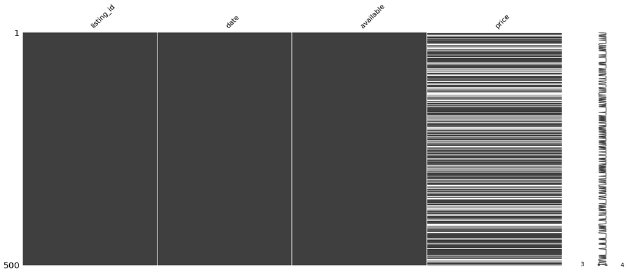

```python
msno.matrix(calendar_pd.sample(500))
```

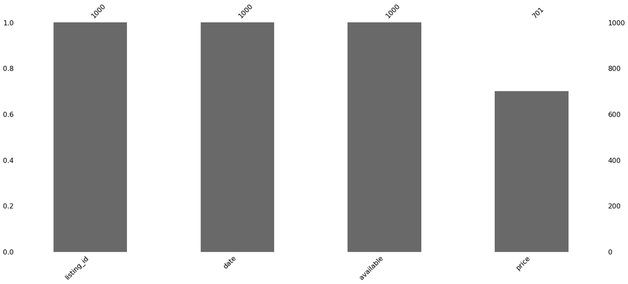

```python
msno.bar(calendar_pd.sample(1000))
```

## We'll focus on listings.csv

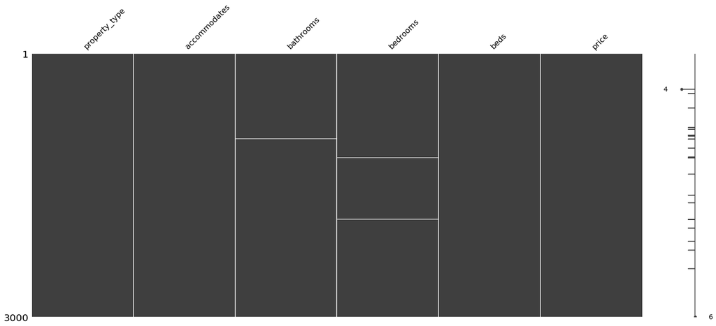

```python
msno.matrix(listings_pd[['property_type', 'accommodates', 'bathrooms', 'bedrooms', 'beds', 'price']].sample(3000))
```

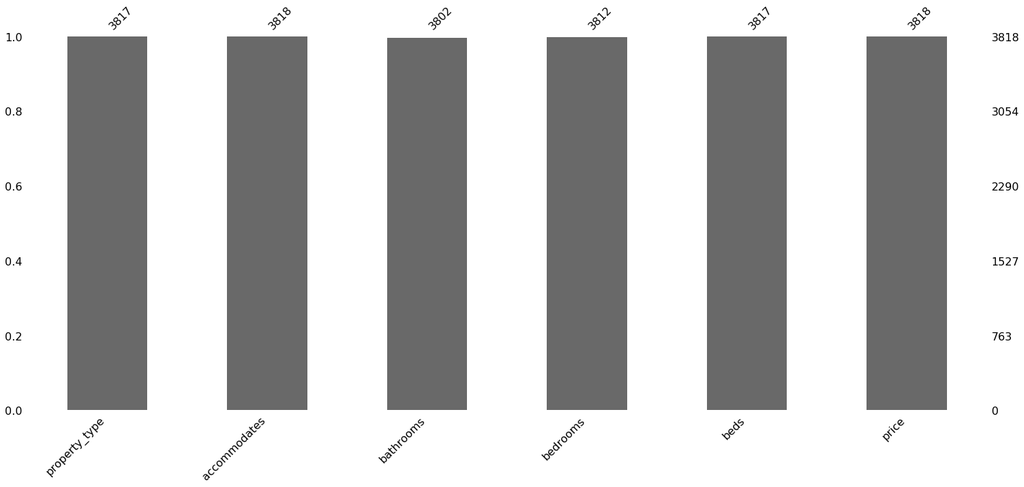

```python
msno.bar(listings_pd[['property_type', 'accommodates', 'bathrooms', 'bedrooms', 'beds', 'price']])
```

## Observations from missing values:

#### calendar.csv

- As we can observe for calendar.csv the price column has a significant amount of missing values, and luckily in this case the way to deal with these missing values are quite simple.
- The missing values in price column is directly related to the false values in the availability column.
- This means that when the dates for which the listings are not available the price is nan, this can be due to the fact that the listings are either already booked or are under maintance. And since the latter is a rare occurance so we will assume that the former is the case.

#### listings.csv

- As we can observe for listings.csv the missing values are really negligible, so even if we drop the rows for the missing values we wont incur much loss.

# Step 2.1 & 2.2 : Data prep and analysis for calendar.csv

We modify the calendar dataframe to add new column for month and weekday for that particular date. This will help us analyze whether there is some pattern for the availibility of the listings with respect to the day of the week and month

```python
calendar_pd['weekday'] = [datetime.strptime(calendar_pd.iloc[i,1],'%Y-%m-%d').weekday() for i in range(len(calendar_pd.iloc[:]))]
```

Changing the available column from text t or f values to numerical 1 or 0 values.

```python
calendar_pd['available'] = [1 if i=='t' else 0 for i in calendar_pd.iloc[:,2]]
```

```python
calendar_pd['month'] = [i.split('-')[1] for i in calendar_pd.iloc[:,1]]
```

```python
len(calendar_pd.listing_id.unique())
```

```
3818
```

## Analysis on rate of availibility of the listings:

- On the basis of day of the week
- On the basis of month of the year

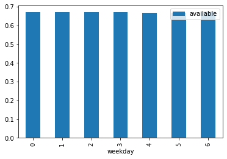

```python
calendar_pd.groupby(['weekday']).mean().plot.bar(y = 'available')
```

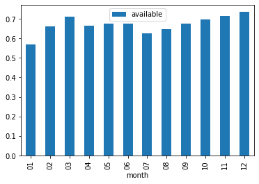

```python
calendar_pd.groupby(['month']).mean().plot.bar(y = 'available')
```

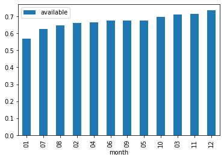

```python
calendar_pd.groupby(['month']).mean().sort_values(by = 'available').plot.bar(y = 'available')
```

As we can observe that there is very little to no difference in the availability of the listing in terms of day of the week but here is some difference(not much but still more then weekday) for the months.

## Analysis on the price rate of the listings

Now lets do some analysis on the prize of the listings and how they varry with respect to the day of the week and month.

The rows are dropped which have nan values in the price columns. This is done because it would help convert the prices values to float and will make it accessible to future analysis, like month wise price comparisons.

```python
calendar_pd_nonan = calendar_pd.dropna()
```

```python
calendar_pd.shape[0], calendar_pd_nonan.shape[0]
```

```
(1393570, 934542)
```

```python
calendar_pd_nonan['price'] = [float(i.strip()[1:].replace(',','')) for i in calendar_pd_nonan.iloc[:,3]]
```

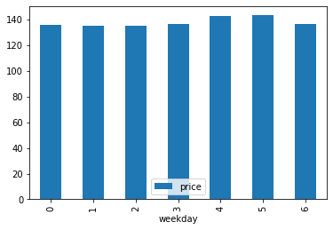

```python
calendar_pd_nonan.groupby(['weekday']).mean().plot.bar(y = 'price')
```

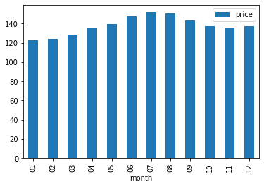

```python
calendar_pd_nonan.groupby(['month']).mean().plot.bar(y = 'price')
```

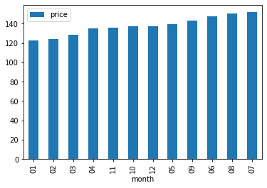

```python
calendar_pd_nonan.groupby(['month']).mean().sort_values(by = 'price').plot.bar(y = 'price')
```

## Observations from calendar.csv :

- The rate of availability varies by some amount when compared with repect to month of the year but not with respect to the days of the week.
- The price rates varies for both day of the week and month of the year.
- The rate of availability can vary due to two reasons:
  - The listing is already booked
  - The listing is down for repair
  - The second reason is rare and will not show any significant change in the patterns.
  - So we will assume that all of the times when listing is not availabe it is because they are already occupied.
- From the variation in the rate of availability with respect to the month we can observe the following things:
  - The listings are occupied the most during the months (In descending order):
    - january
    - july
    - august
  - The listings are occupied the least during the months (In descending order):
    - December
    - November
    - March
- From the variation in the price with respect to the month we can observe the following things:
  - The listings are priced highest during the months (In descending order):
    - July
    - August
    - June
  - The listings are priced lowest during the months (In descending order):
    - January
    - February
    - March
- From the above observations we can infer the following things:

**What is the best month to visit seattle if you are on a budget?**

```
- January, February and March are months where the price rates are the lowest. Especially in january and that is the reason most of the listings are occupied in January. And the listings are relatively less occupied in february and march because the prices rates starts increasing again.
- So if people want to enjoy their time in seattle with a slightly less cold weather but still fairly cheap prices February and march is a good time to book an airbnb.
```

**From owners POV what is the best time to list your propery on Airbnb? And how to set price rates according to the time of the year?**

```
- On the other hand the summers especially in the month of July, August and June the price rates are the heighest because it is a comfortable weather and that is when most of the tourists come and visit seattle.
- So from a buissness point of view if you are planning to list your property on airbnb and want to maximize your profits you should set your prices high during the summer season as the volume of tourist are already very high and most of the hotels will already be fully booked so there are chances that people would be willing to pay high amount of money to find a place to stay. On the other hand january is the month when you should set your prices to be budget friendly because that is what will attract people to book your listing in that cold weather.
```

**What is the best time in year when owners can take down their listing for maintainance and repair?**

```
- From owners point of view the best months to get the listings repaired without incurring a major loss would be in the month of November and December.
```

# Step 2.3 & 2.4 : Data prep and analysis for listings.csv

## We will first explore the spatial information using the seattle census tract data.

- Instead of using normal pandas Dataframe and series we will use geopandas geoDataframe and geoseries as it handles geo-spatial features and geometric shapes and areas much more efficiently.

```python
seattle = gpd.read_file("./Census_Tracts_2010/Census_Tracts_2010.shp")
```

```python
seattle.head()
```

|  | OBJECTID | TRACT | TRACTCE10 | GEOID10 | NAME10 | NAMELSAD10 | ACRES_TOTA | WATER | SHAPE_Leng | SHAPE_Area | geometry |
| --- | --- | --- | --- | --- | --- | --- | --- | --- | --- | --- | --- |
| 0 | 1 | 2500 | 002500 | 53033002500 | 25 | Census Tract 25 | 243.219083 | 0 | 16442.968402 | 1.059462e+07 | POLYGON ((-122.29602 47.69023, -122.29604 47.6... |
| 1 | 2 | 2600 | 002600 | 53033002600 | 26 | Census Tract 26 | 307.584420 | 0 | 15936.137058 | 1.339838e+07 | POLYGON ((-122.30817 47.69031, -122.30793 47.6... |
| 2 | 3 | 5600 | 005600 | 53033005600 | 56 | Census Tract 56 | 737.511727 | 0 | 30337.294354 | 3.212601e+07 | POLYGON ((-122.39300 47.63956, -122.39300 47.6... |
| 3 | 4 | 6800 | 006800 | 53033006800 | 68 | Census Tract 68 | 177.438771 | 0 | 11275.376490 | 7.729233e+06 | POLYGON ((-122.35070 47.63994, -122.35071 47.6... |
| 4 | 5 | 6000 | 006000 | 53033006000 | 60 | Census Tract 60 | 324.567432 | 0 | 19729.922875 | 1.413816e+07 | POLYGON ((-122.34279 47.64320, -122.34267 47.6... |

```python
seattle['geometry'].head()
```

```
0    POLYGON ((-122.29602 47.69023, -122.29604 47.6...
1    POLYGON ((-122.30817 47.69031, -122.30793 47.6...
2    POLYGON ((-122.39300 47.63956, -122.39300 47.6...
3    POLYGON ((-122.35070 47.63994, -122.35071 47.6...
4    POLYGON ((-122.34279 47.64320, -122.34267 47.6...
Name: geometry, dtype: geometry
```

```python
seattle['geometry'][1]
```

[output not shown]

**As you can see the geometry colum contains the latitude and longitude points which make up the polygonal shape of each of the census tract.**

```python
seattle.crs
```

```
<Geographic 2D CRS: GEOGCS["WGS 84",DATUM["WGS_1984",SPHEROID["WGS 84" ...>
Name: WGS 84
Axis Info [ellipsoidal]:
- lon[east]: Longitude (Degree)
- lat[north]: Latitude (Degree)
Area of Use:
- undefined
Datum: World Geodetic System 1984
- Ellipsoid: WGS 84
- Prime Meridian: Greenwich
```

```python
seattle = seattle.to_crs({'init': 'epsg:4326'})
```

```python
seattle['geometry'].head()
```

```
0    POLYGON ((-122.29602 47.69023, -122.29604 47.6...
1    POLYGON ((-122.30817 47.69031, -122.30793 47.6...
2    POLYGON ((-122.39300 47.63956, -122.39300 47.6...
3    POLYGON ((-122.35070 47.63994, -122.35071 47.6...
4    POLYGON ((-122.34279 47.64320, -122.34267 47.6...
Name: geometry, dtype: geometry
```

**geopandas objects have a plot method which plots your geometry into a matplotlib plot right away as shown:**

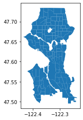

```python
seattle.plot()
```

**Upconverting the latitude and longitude points in listings_pd Dataframe into geospatial shapely points which are also used under the hood of the geopandas library. This would help to use the latitude and longitude information in listings_pd with the geospatial information in the seattle geoDataframe.**

## Checking the density of BNB's

```python
listings_geo_pd = gpd.GeoDataFrame(listings_pd, geometry=listings_pd.apply(
        lambda srs: shapely.geometry.Point(srs['longitude'], srs['latitude']), axis='columns'
    ))
```

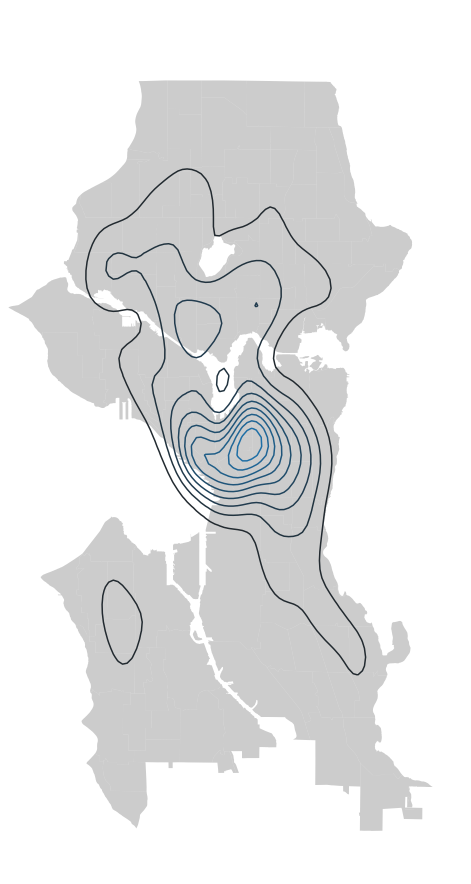

```python
f = plt.figure(figsize=(25, 16))
ax = f.gca()

seattle.plot(ax=ax, alpha=0.4, linewidth=0.25, color='grey')
sns.kdeplot(data=listings_geo_pd.apply(lambda srs: pd.Series({'x': srs.geometry.x, 'y': srs.geometry.y}), axis='columns'), ax=ax,
            alpha=1)
ax.set_axis_off()
```

```python
def assign_census_tract(bnb):
    ''' creates a bools list which is a lists that
    consists of boolean values for the census tracts that the
    latitude and longitude point lies in.

    Attributes:
        bnb: The dataframe on which we want to get the bools list.

    Returns:
        nan value if there is none of the values are True in the bools list.
        else returns list containing the census tract types for the element
        in the dataframe.
    '''
    bools = [geom.contains(bnb['geometry']) for geom in seattle['geometry']]
    if True in bools:
        return seattle.iloc[bools.index(True)]['NAMELSAD10']
    else:
        return np.nan
```

**Create a new column in the geoDataframe that will help us create a more precise representation of the density of the BNBs on the map.**

```python
listings_geo_pd['census_tract'] = listings_geo_pd.apply(assign_census_tract, axis='columns')
```

```python
listings_geo_pd['census_tract']
```

```
0          Census Tract 69
1          Census Tract 69
2       Census Tract 58.02
3          Census Tract 69
4       Census Tract 58.02
               ...
3813       Census Tract 48
3814                   NaN
3815                   NaN
3816                   NaN
3817                   NaN
Name: census_tract, Length: 3818, dtype: object
```

```python
seattle['BNBs'] = seattle['NAMELSAD10'].map(listings_geo_pd['census_tract'].value_counts())
```

```python
def choropleth(col):
    '''Creates a chloropleth plot which tells about the density of the col(it can be any float or integer col
    in our case its the BNBs, BNB_density and price column)'''
    f = plt.figure(figsize=(30, 20))
    ax = f.gca()
    kw = dict(column=col, k=6, cmap='YlGn', alpha=1, legend=True, edgecolor='gray', linewidth=0.5)
    seattle.plot(scheme='QUANTILES', ax=ax, **kw)
    seattle.apply(lambda x: ax.annotate(fontsize= 7, s=x['NAMELSAD10'], xy=x.geometry.centroid.coords[0], ha='center'), axis=1);
    ax.set_axis_off()
```

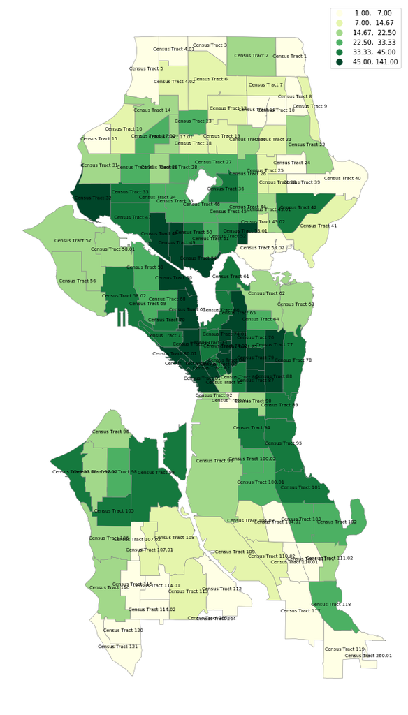

```python
choropleth('BNBs')
```

**There is one fault in the above plot, that is the bigger the area the more bnbs will be there in that tract, which does not give a fiar measure of how BNB dense the tract is instead we need to calculate the density of the BNB's in the tract.**

```python
seattle['BNBDensity'] = (seattle['BNBs'] / seattle['geometry']\
                            .to_crs({'init': 'epsg:3395'})\
                            .map(lambda p: p.area / 10**6))\
                            .fillna(0)
```

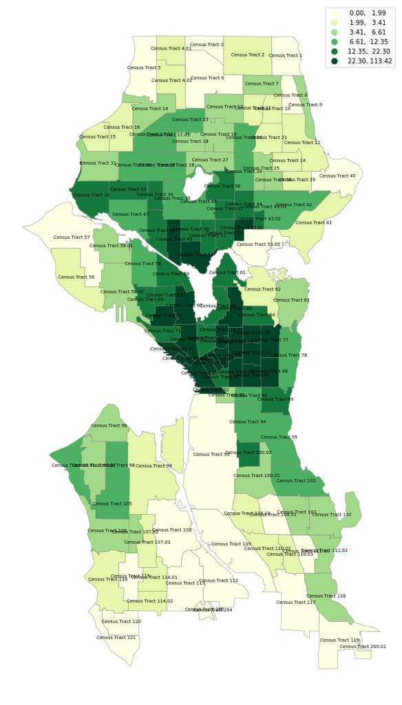

```python
choropleth('BNBDensity')
```

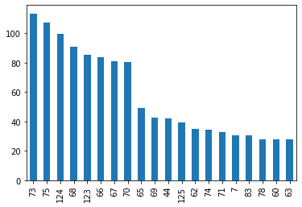

```python
seattle['BNBDensity'].sort_values(ascending=False)[:20].plot.bar(x='NAMELSAD10')
```

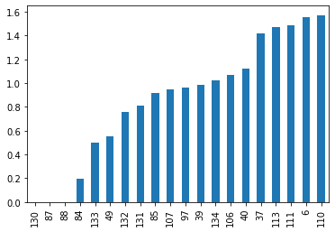

```python
seattle['BNBDensity'].sort_values(ascending=True)[:20].plot.bar(x='NAMELSAD10')
```

# Observations for BNB density:

- From the above choropleth and bar plots we can observe that tract 73, 75, 124, 68, 123... have highest density of BNB's in it. And the tracts 130, 87, 88 , 84, 133... have the lowest density of BNB's.

## Exploring the type of bnbs on the basis of type, price, accomodation, rooms, beds

```python
listings_pd_ppl = listings_geo_pd[['property_type', 'accommodates', 'bathrooms', 'bedrooms', 'beds', 'price', 'geometry','census_tract']]
```

```python
listings_pd_ppl_nonan = listings_pd_ppl.dropna()
```

```python
listings_pd_ppl.shape[0], listings_pd_ppl_nonan.shape[0]
```

```
(3818, 3790)
```

```python
listings_pd_ppl_nonan['price'] = [float(i.strip()[1:].replace(',','')) for i in listings_pd_ppl_nonan['price']]
```

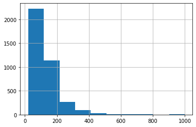

```python
listings_pd_ppl_nonan['price'].hist()
```

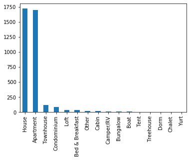

```python
listings_pd_ppl_nonan['property_type'].value_counts().plot.bar()
```

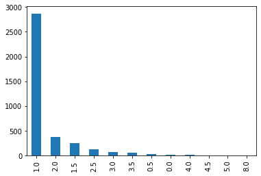

```python
listings_pd_ppl_nonan['bathrooms'].value_counts().plot.bar()
```

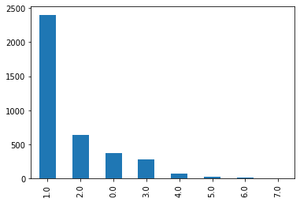

```python
listings_pd_ppl_nonan['bedrooms'].value_counts().plot.bar()
```

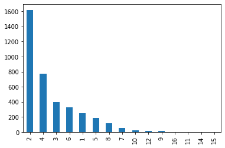

```python
listings_pd_ppl_nonan['accommodates'].value_counts().plot.bar()
```

# Observations for type of listings:

- We can observe that high density of BNB's are in the price rate of 30-200\$ and the exotic luxury ones are very rare.
- Houses and Apartments are the most common kind of property types in Seattle.
- 1 bedroom and bathroom accomodations are most common.
- And most of the BNB's 2 or 4 number of peoples.

## Scatter plot for visualizing the density of the types of airbnbs in different regions of seattle

```python
def plot_scatter(col, type = ''):
    '''Plots a scatter plot on the seattle map.
    the size of the points in the scatter plot is dependent on the
    price of the listings.

    Attributes:
        col: column that we want to visualize on the seattle map,
        it can be property_type, bedrooms, accomodates column
        type: For the given column we can visualize any particular
        value. eg. for property_type column we can visualize where
        the apartments are in seattle
    '''

    fig, ax = plt.subplots(figsize=(25, 16))
    sample = listings_pd_ppl_nonan.sample(1500)
    colors = np.random.rand(len(listings_pd_ppl_nonan[col].unique()))
    base = seattle.plot(ax=ax, alpha=0.4, linewidth=0.25, color='grey')
    sns.kdeplot(data=listings_pd_ppl_nonan.apply(lambda srs: pd.Series({'x': srs.geometry.x, 'y': srs.geometry.y}), axis='columns'), ax=ax,
            alpha=1)
    if type == '':
        for i in listings_pd_ppl_nonan[col].unique():
            x_cor = sample[sample[col]==i].geometry.x
            y_cor = sample[sample[col]==i].geometry.y
            ax.scatter(x_cor,y_cor,label=i, s = sample['price'],alpha=0.5)
    else:
        x_cor = sample[sample[col]==type].geometry.x
        y_cor = sample[sample[col]==type].geometry.y
        ax.scatter(x_cor,y_cor,label=type, c= colors, s = sample['price'],alpha=0.5)

    ax.legend()
    ax.set_axis_off()
```

**scatter plot to see the densities of various properties types in different regions of seattle.**

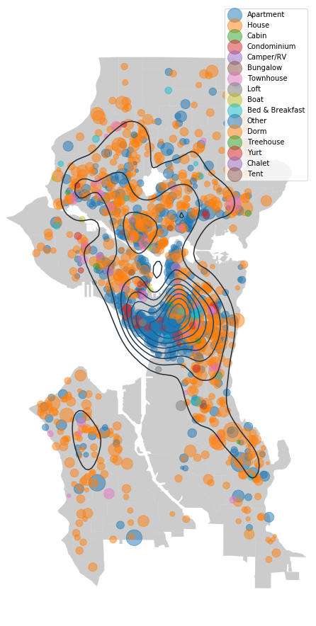

```python
# f = plt.figure(figsize=(25, 16))
# ax = f.gca()
plot_scatter('property_type')
```

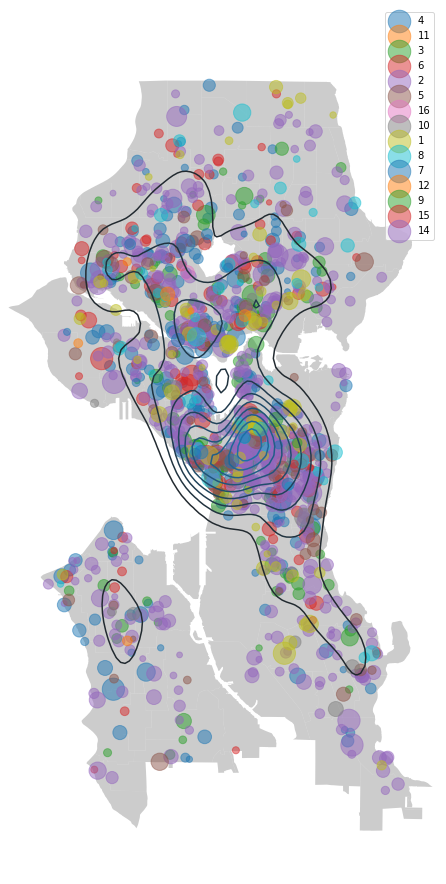

```python
plot_scatter('accommodates')
```